# 09_14_17_checkin

Molly Jenkins

September 14, 2017

# Occupancy-scale analysis

#### Summary

This script takes a dataset of BBS routes with occupancy values calculated for every scale, scales ranging in size from 1/10th of a BBS route to 66 aggregated BBS routes. Using this data we analyze the relationship between temporal occupancy of communities and scale. We characterize this relationship in a series of simple linear models between occupancy and scale (using log(area) as our variable of spatial scale). From these models and our existing data, for every focal route we traced how occupancy changes across scale, from smallest to largest scale.

We characterized these changes through a series of variables:

1. the occupancy value at the minimum scale for a focal route
2. the occupancy value at the maximum scale for a focal route
3. the slope of the line linking the minimum and maximum values - the steepness (or flatness) of this line corresponds with the rate of accumulation of core species for a given community
4. the midpoint occupancy value of the line at the scale of 3 aggregated routes per focal route - The value of mean occupancy for the community at this scale is also a useful proxy for the rate of accumulation of core species for a given community
5. the scale at which mean occupancy first reaches or surpasses 50% - At what scale, at what area in km must we reach in order to reliably see consistent occupancy? PREDICTION: in areas of fairly uniform habitat type, this scale should be lower PREDICTION: in areas of fairly high habitat heterogeneity, this scale should be higher
6. finally, we look at the variation in occupancy explained by scale thru R^2 values
7. and we look at the straightness or curviness of the actual data as compared to the data derived from our model. PREDICTION: focal routes with larger “curvy” values will occur in regions of greater habitat heterogeneity, and deviance from the line will correspond with the greater environmental variance associated with the location of that focal route. i.e. curvy is a proxy for AUC, where greater deviance of the predicted vals vs the actual vals will result in larger overall curvy values and larger area under the curve

We explore the variation in this relationship and attempt to characterize whether or not it is best explained by habitat heterogeneity using the variation present across several environmental variables as proxies for habitat heterogeneity.

### CURRENT ISSUES

#### revised 09/10/2017

1. Have below-scale duplicates w/diff starting locations i.e. “scale” = Factor w/83 levels “10-1”, “10-2”, “10-3”, “10-4”, “10-5”, “5-1”, “5-2”, “5-3”, “5-4”, “5-5”, “5-6”, “5-7”, “5-8”, etc. no duplicates for 1:66 obvi, these were calculated correctly can I have multi values for a single scale or should I calc avg occ and pctCore and pctTran across the segments w/in a route? i.e. occ/15 at a scale, but scales designated by segments and occ calcd initially based on the starting stop number. I was told this summer that that was alright and that we were pointedly NOT aggregating across the lower scales, and that’s fine - BUT: it DOES mean we will have pseudo-duplicates at the lower scales w/diff starting points of segments, and so multiple plotting points for the lower scales instead of a single representative point. This necessitates the “min” qualifier in calculating some of the coefficients.
2. In calculating the AUC proxy “curvy” values, should I be squaring the differences before summing them? Because we are interested in the magnitude of deviance from the observed values in instances of greater heterogeneity, and not the specific direction - simply adding them could cancel out or diminish the magnitude or gulf of deviance in areas where the deviance is large in a negative direction at some scales, and large in a positive direction in others. These stateroutes would express similar “curviness” values as areas of high homogeneity, where this is little net difference and a smaller magnitude of deviance from the observed values. Because of this, I think we should be squaring and summing.
3. Curviness is a great proxy for calculating the AUC per focal route, but it doesn’t allow us to see how that changes across scales. Considering having a second df output from the creation of coefs that allows us to see how those individual deviances change, esp across scales.

Changes in the frequency of occupancy values at different scales:

```r
#work in progress

bbs_allscales = read.csv("data/BBS/bbs_allscales.csv", header = TRUE)
coefs = read.csv("scripts/R-scripts/scale_analysis/coefs.csv", header = TRUE)
goodrtes = read.csv(paste(BBS, "good_rtes2.csv", sep = ""), header = TRUE)


#merge longi and lati to bbs_allscales prior to east vs west plotting
bbs_allscales = bbs_allscales %>%
  left_join(goodrtes, by = c("focalrte" = "stateroute"))


#plot observed occ scale thresh or mid vals vs pthresh or pmid vals across scales
#subtract actual - pred to gen new column of AUC vals for each scale

#first plot freqs of occupancy vals with vals binned every .05 and .1 incremements for diff scales:

#First plots: scale = 1, x axis = meanOcc, y axis = freq of meanOcc vals (hist)
bbs_one = bbs_allscales %>%
  filter(scale == "50-1")

bbs_one_E = bbs_one %>%
  filter(Longi > -100) #greater than -100 is -99, -98, -97 etc.
bbs_one_W = bbs_one %>%
  filter(Longi <= -100 ) #less than or equal to -100 is further away from 0 and further negative

#Second comparison plots: scale = 66, x-axis = meanOcc, y axis = freq of meanOcc vals (hist)
bbs_top = bbs_allscales %>%
  filter(scale == "66")

bbs_top_E = bbs_top %>%
  filter(Longi > -100)
bbs_top_W = bbs_top %>%
  filter(Longi <= -100)
```

## Plotting comparisons of temporal occupancy frequency distributions at different scales

compare btw/East vs West N. American routes, split in half and compare to predicted whiteboard sketches Preliminary, in place of an index of homogeneity, I use East vs West to examine differences in habitat homogeneity and scale.

Since statecode/focalrte names aren’t assigned in order from East to West, I filtered by greater than or less than a longitudinal cutoff of 100 degrees.

### NEXT STEPS:

Will the next step be adding our environmental data to the different routes at different scales, and rerunning these investigative plots using that instead of relying on the preliminary East vs West category? That way, we can more concretely separate and compare homogeneity/heterogeneity and scale.

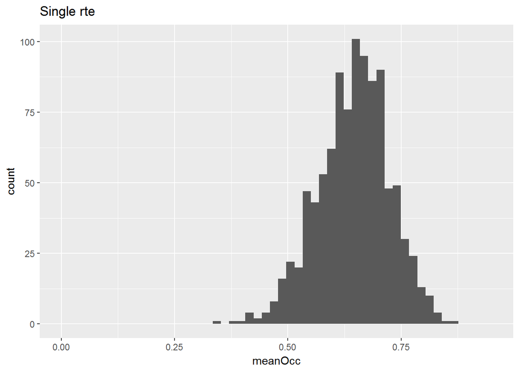

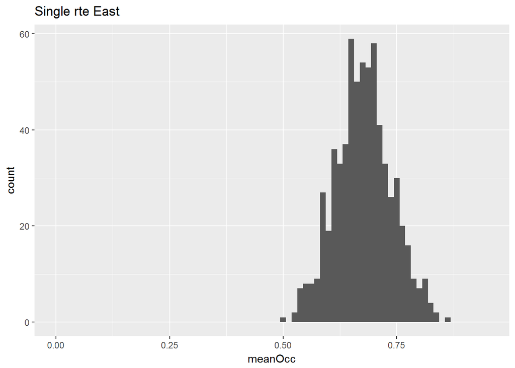

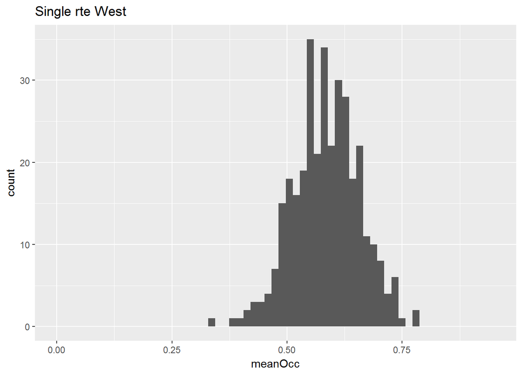

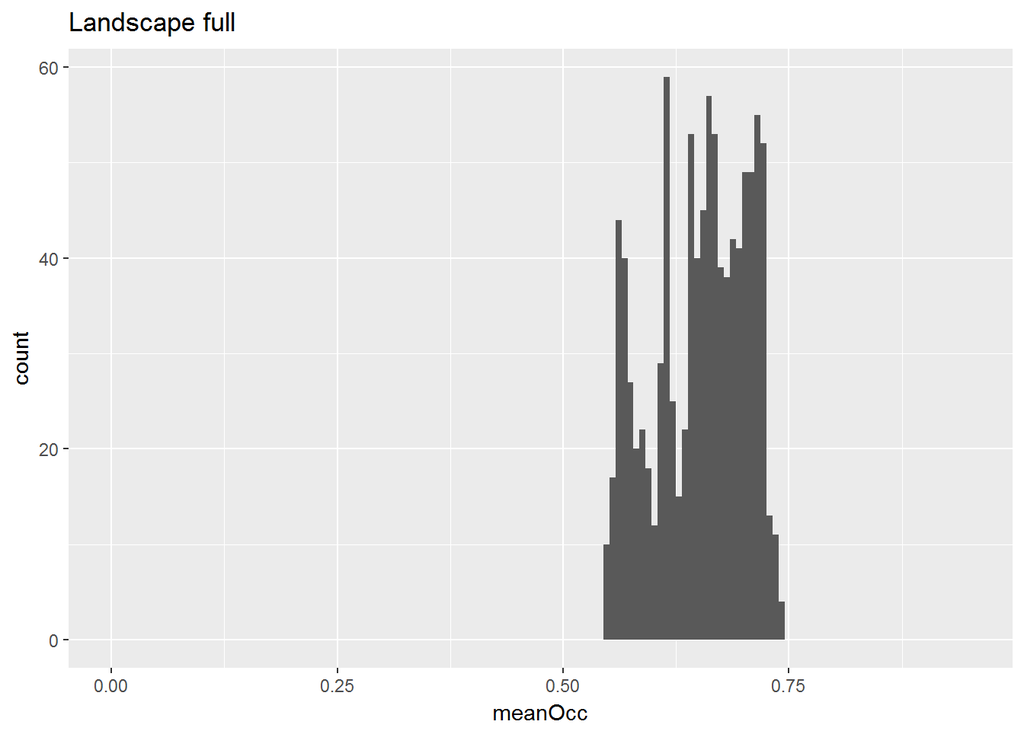

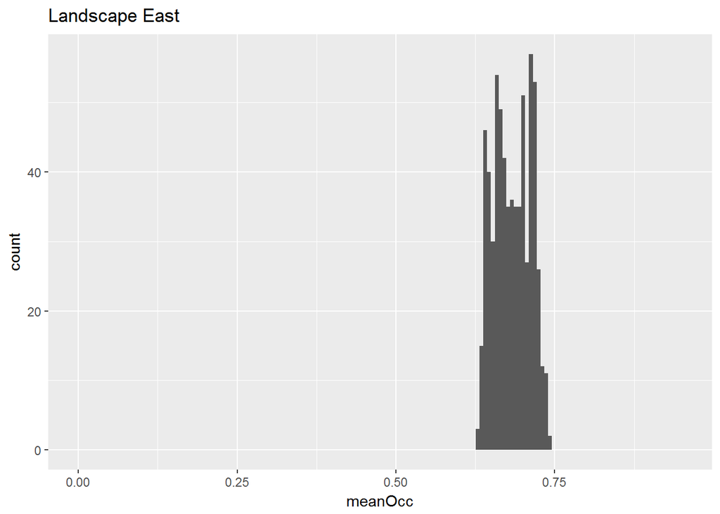

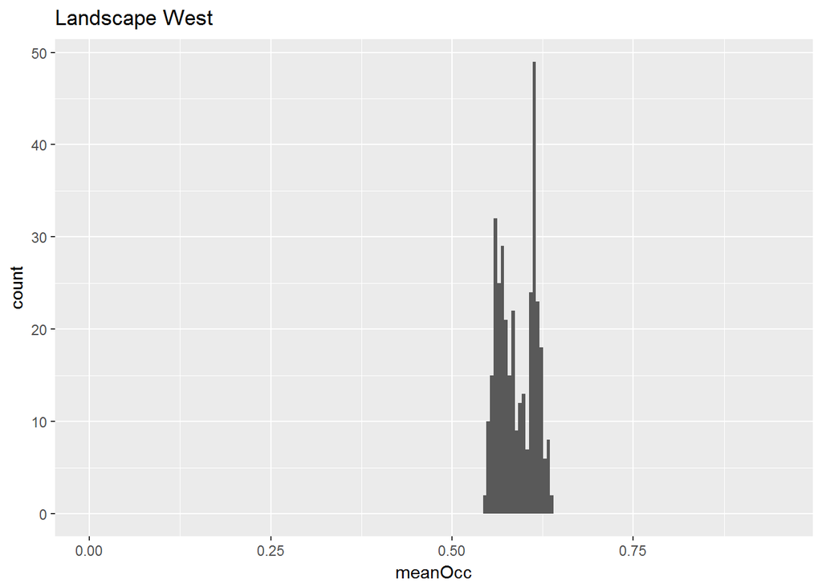

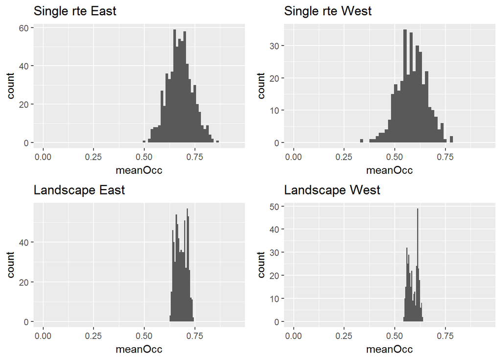

Now plot ‘curvy’ stats at different routes -> effectively summarizing area under curve across scales for each route. AUC should vary with scale, but also with east vs west divide/hetero vs homogeneity divide. Greater AUC vals in West = greater deviance from observations on avg across scales.

### NEXT STEPS:

Are we interested in seeing the way that AUC varies across SCALES instead of summarizing it for each route? so y axis = curvy, x axis = (?) The MAGNITUDE and the DIRECTION of deviance matters - we could get the same or similar ‘curvy’ values for two totally different routes, but the scales at which there is greatest deviance or the way that deviance is distributed across scales may be completely different. Does this matter for our purposes?

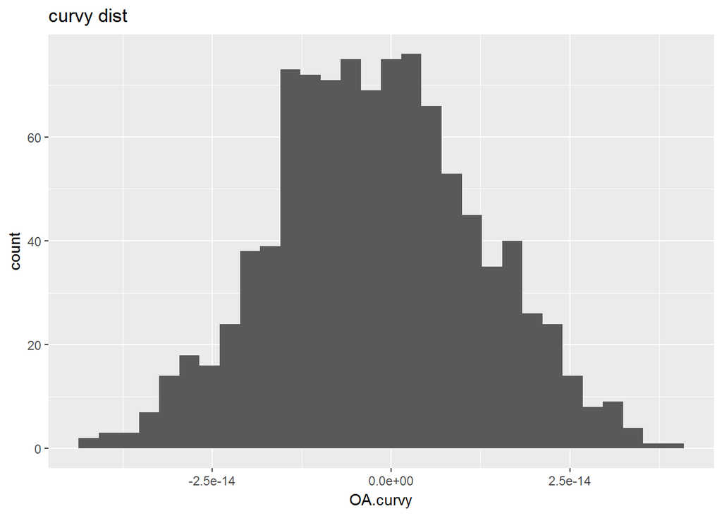